# COVID-19 Research Project

### BIOL390: Reproducible Research, Summer 2020

**Copyright © (2020) Bethany Riess**

## A. Abstract (tl;dr)

COVID-19 research project evaluating the COVID-19 trends from states that never issued stay-at-home orders compared to states that did. The information gathered for this project took place from the beginning of the pandemic until August 16th, 2020.

## B. Introduction

COVID-19 (*Orthocoronavirinae*) is the name given to the virus that has caused a pandemic starting at the end of 2019. This virus is also known as SARS‑CoV‑2.First identified in December of 2019, the virus outbreak began in Wuhan, China and quickly sread throughout the globe. The World Health Organization (WHO) declared it an International Public Health Emergency [^1], and many states in the United States responded quickly, implementing regulations in hope of decreasing the spread of COVID-19, and slowing its effect on the population. Some states chose to shut down almost entirely, closing gyms, theaters, bowling alleys, restaurants, and much more. While many states were quick to issue stay-at-home orders, some states were determined to stay much more open for the height of the pandemic. Seven states chose not to issue stay-at-home orders during the pandemic. These states were Arkansas, Iowa, Nebraska, North Dakota, South Dakota, Utah, and Wyoming.One of these states, South Dakota, also did require the closure of any businesses (although in-person education at schools was closed in all 7 states.)[^2]

## C. Hypothesis

The intention of the stay-at-home orders was to limit interactions from members of the population in hopes of avoiding contact that would spread COVID-19. Based on this idea, the states that did not issue stay-at-home orders should have higher rates of COVID-19 cases than the states that did issue stay-at-home order.

## D. Datasets used

The primary dataset used for this analysis is the “United States COVID-19 Cases and Deaths by State” compiled by the CDC and published on Data.CDC.gov.

## E. Description of analyses

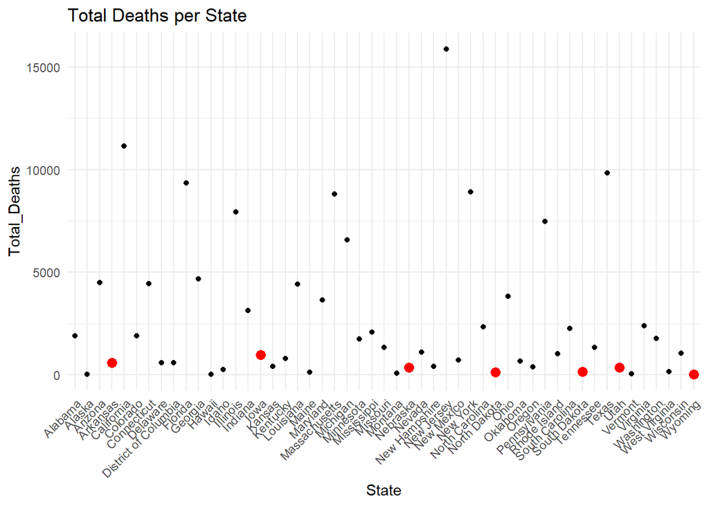

**Figure 1:** Total deaths per state. States that did not implement a stay-at-home order are red.

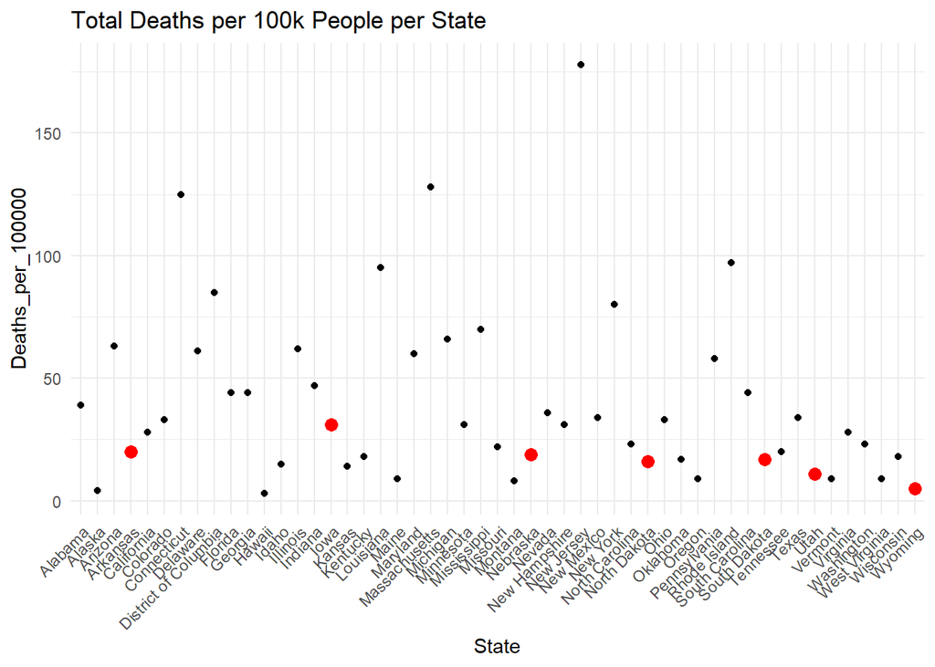

**Figure 2:** Total deaths per 100k people per state. States that did not implement a stay-at-home order are in red

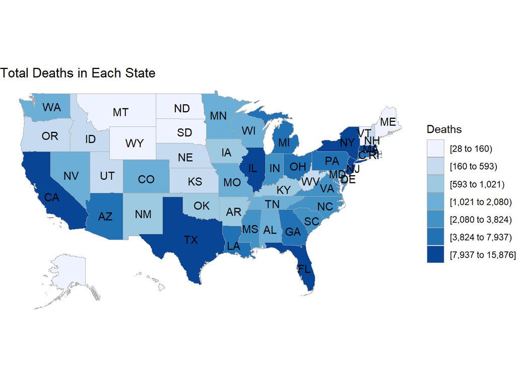

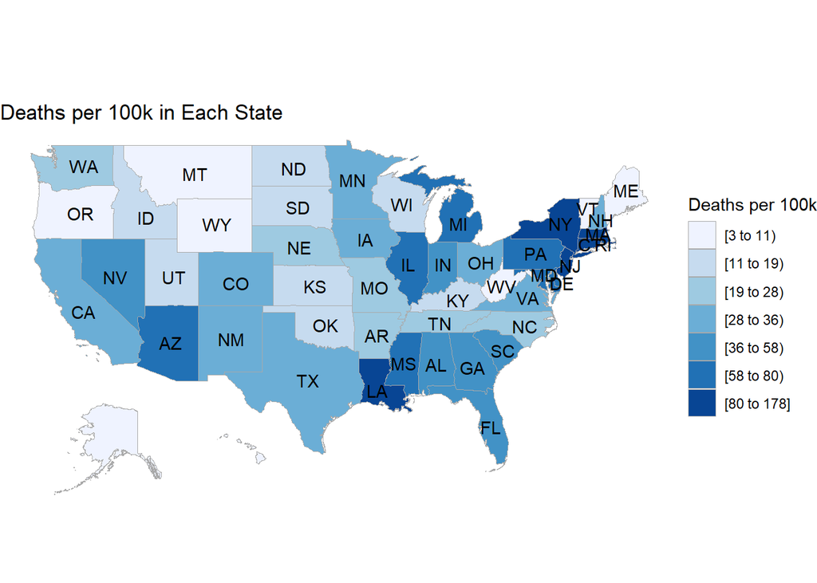

## G. Viewing this project

The completed project files can be accessed online at (https://github.com/riessb12/COVID-19). The repo for this reproducible project is also publicly available at (https://github.com/riessb12/COVID-19).

[^1]: COVID-19 pandemic. (2020, August 14). Retrieved August 17, 2020, from https://en.wikipedia.org/wiki/COVID-19_pandemic
[^2]: States that did not issue stay-at-home orders in response to the coronavirus (COVID-19) pandemic, 2020. (n.d.). Retrieved August 16, 2020, from https://ballotpedia.org/States_that_did_not_issue_stay-at-home_orders_in_response_to_the_coronavirus_(COVID-19)_pandemic,_2020